# HW5_Q4

Ethan M. Lotz

November 3, 2017

## Question 4

The three custom spotted array data files GMU1420.txt, GMU1421.txt, and GMU1422.txt are three technical replicates whereby the Stratagene Universal Human RNA was hybridized. Read the data into the R programming environment. Use code from in-class exercises, change names of the columns containing Red/Green intensities as to NOT contain spaces, like: name.Gf = âch1Intensityâ

```r
setwd("C:/Users/lotzem/Desktop/School/Classes/BIOS 567/Homework/Homework 5/hw5/q4/")
file <- dir(pattern = "txt")[1:3]
file
```

```
## [1] "GMU1420.txt" "GMU1421.txt" "GMU1422.txt"
```

```r
layout<-read.marrayLayout(fname=file[1], ngr=12, ngc=4, nsr=21, nsc=21, skip=21211)
info<-read.marrayInfo(fname=file[1], info.id=c(1,6), labels=6, skip=21211)
raw.data <- read.marrayRaw(file,
                           name.Gf="ch1Intensity", name.Gb="ch1Background",
                           name.Rf="ch2Intensity", name.Rb="ch2Background",
                           layout=layout, gnames=info, skip=21211)
```

```
## Reading ...  ./GMU1420.txt
## Reading ...  ./GMU1421.txt
## Reading ...  ./GMU1422.txt
```

a.) Produce all chip-specific MA plots.

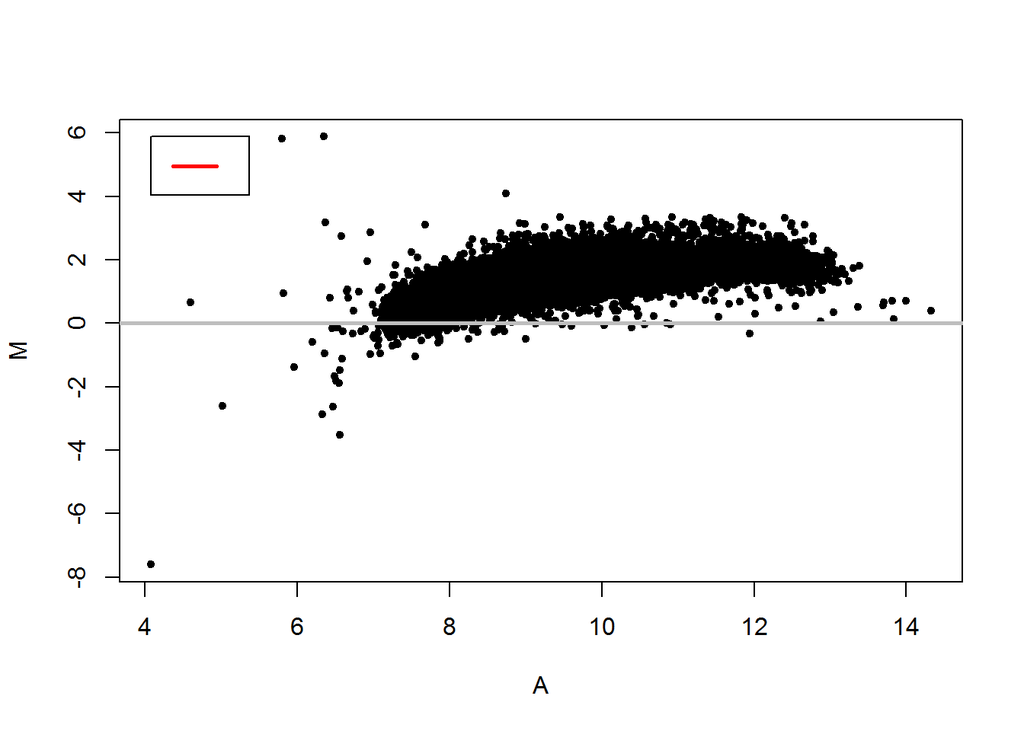

```r
maPlot(raw.data[,1],x="maA",y="maM",z=NULL,lines.func=NULL)
```

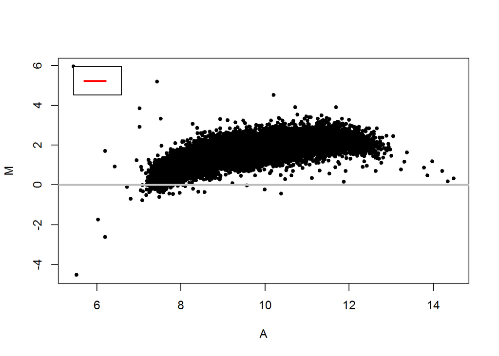

```r
maPlot(raw.data[,2],x="maA",y="maM",z=NULL,lines.func=NULL)
```

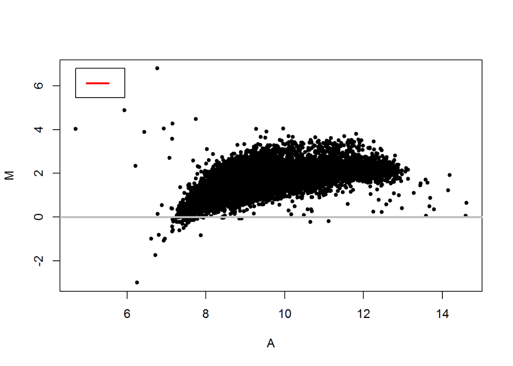

```r
maPlot(raw.data[,3],x="maA",y="maM",z=NULL,lines.func=NULL)
```

b.) For GMU1420.txt, produce a scatterplot of the Green foreground by Green background, as well as a plot of Red foreground by Red background.

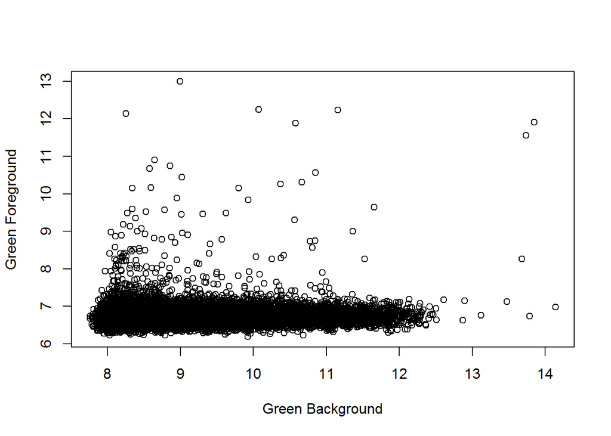

```r
plot(log2(raw.data@maGf[,1]),log2(raw.data@maGb[,1]), ylab="Green Foreground", xlab="Green Background")
```

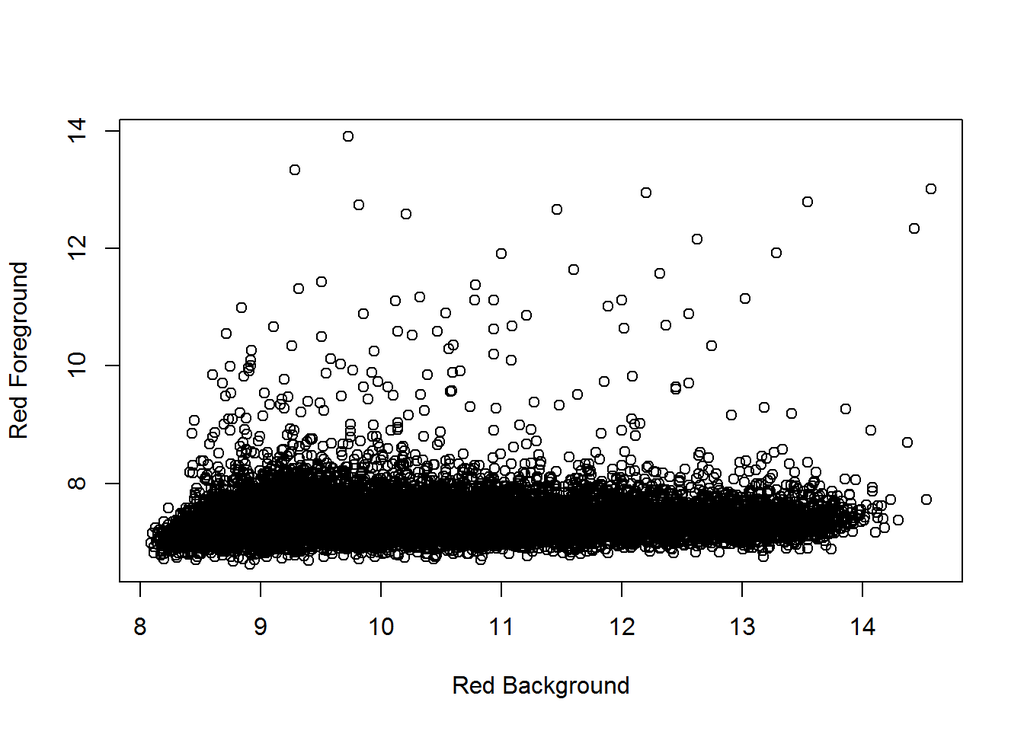

```r
plot(log2(raw.data@maRf[,1]),log2(raw.data@maRb[,1]), ylab="Red Foreground", xlab="Red Background")
```

What, if anything, do these plots suggest?

The range of the red channel is larger than the green channel, but both graphs indicate a constant linear relationship suggesting minimal dye bias.“)

c.) Apply constant global normalization to the raw data; plot the MA plots and boxplots by print-tip for this post normalized data.

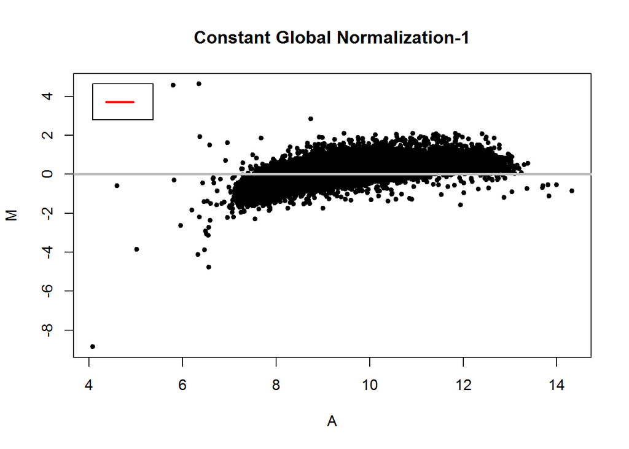

```r
raw.data.norm.m <- maNorm(raw.data, norm="median")

maPlot(raw.data.norm.m[,1],x="maA",y="maM",z=NULL,lines.func=NULL, main="Constant Global Normalization-1")
```

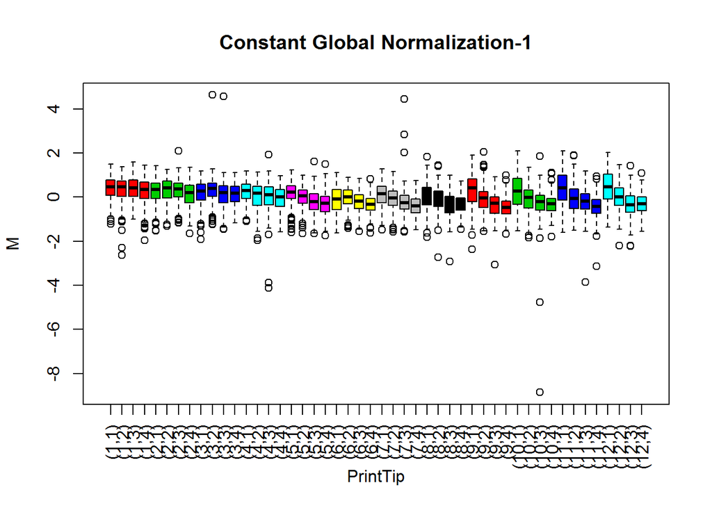

```r
boxplot(raw.data.norm.m[,1], xvar="maPrintTip", yvar="maM", main="Constant Global Normalization-1")
```

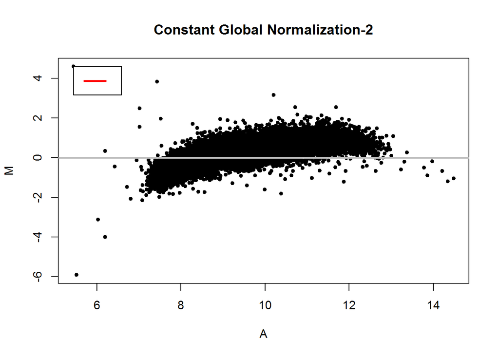

```r
maPlot(raw.data.norm.m[,2],x="maA",y="maM",z=NULL,lines.func=NULL, main="Constant Global Normalization-2")
```

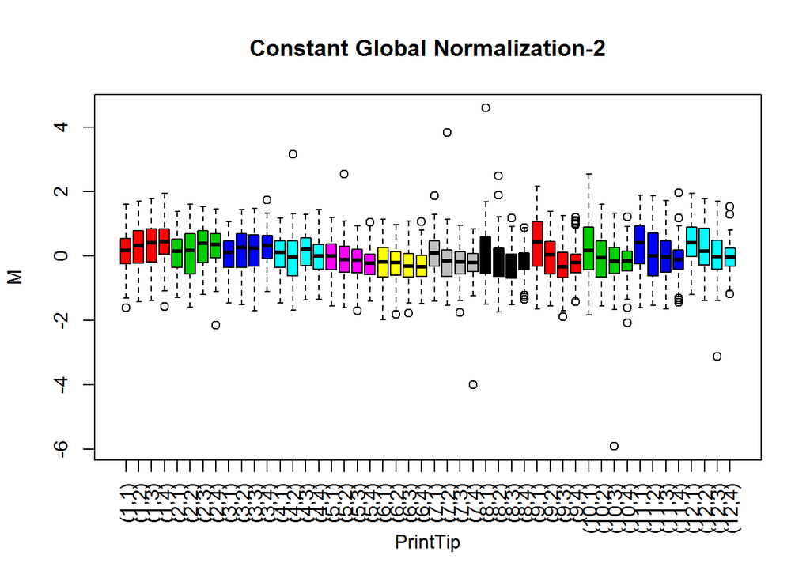

```r
boxplot(raw.data.norm.m[,2], xvar="maPrintTip", yvar="maM", main="Constant Global Normalization-2")
```

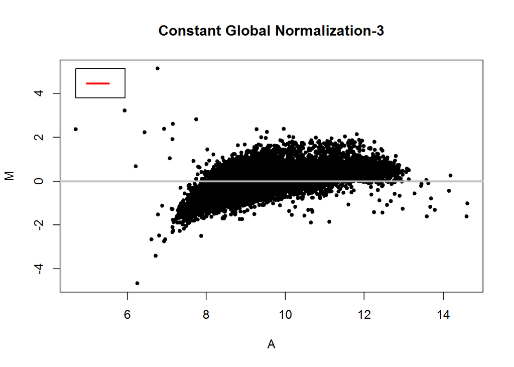

```r
maPlot(raw.data.norm.m[,3],x="maA",y="maM",z=NULL,lines.func=NULL, main="Constant Global Normalization-3")
```

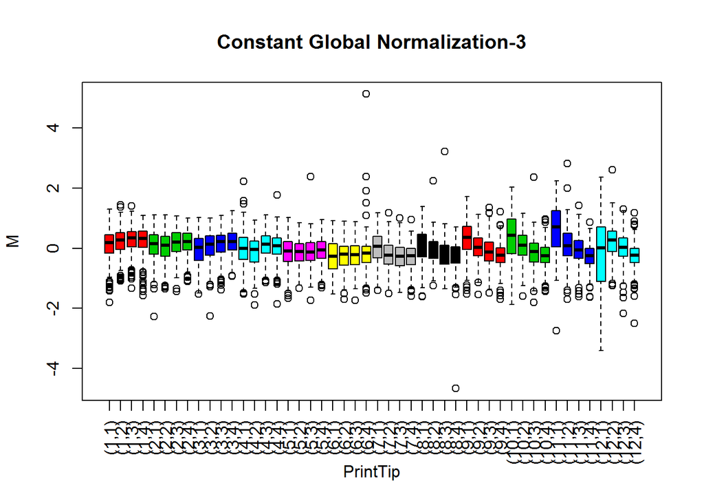

```r
maBoxplot(raw.data.norm.m[,3], xvar="maPrintTip", yvar="maM", main="Constant Global Normalization-3")
```

d.) Apply global loess normalization to the raw data; plot the MA plots and boxplots by print-tip for this post normalized data.

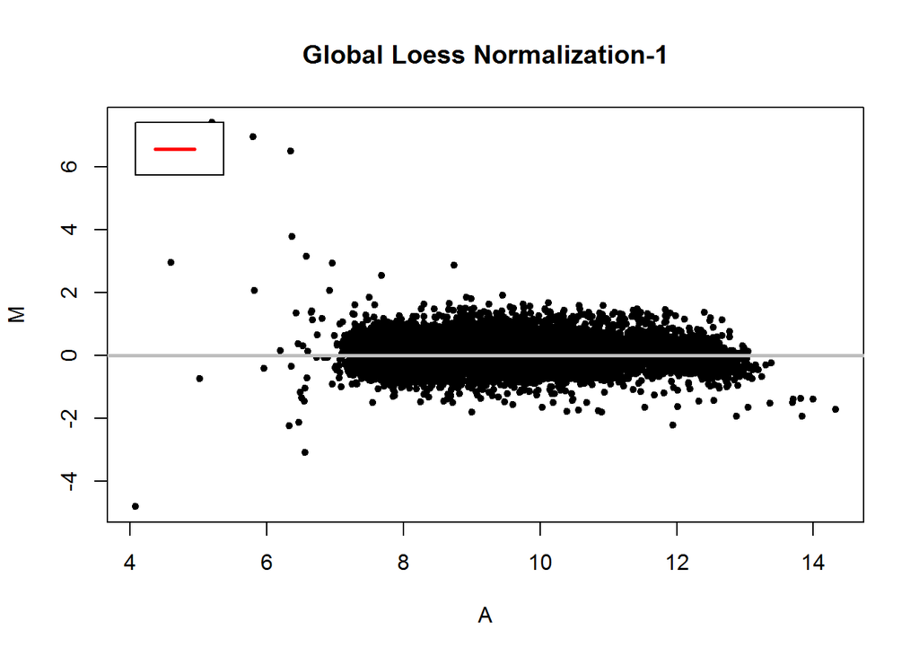

```r
raw.data.norm.l <- maNorm(raw.data, norm="loess")

maPlot(raw.data.norm.l[,1],x="maA",y="maM",z=NULL,lines.func=NULL, main="Global Loess Normalization-1")
```

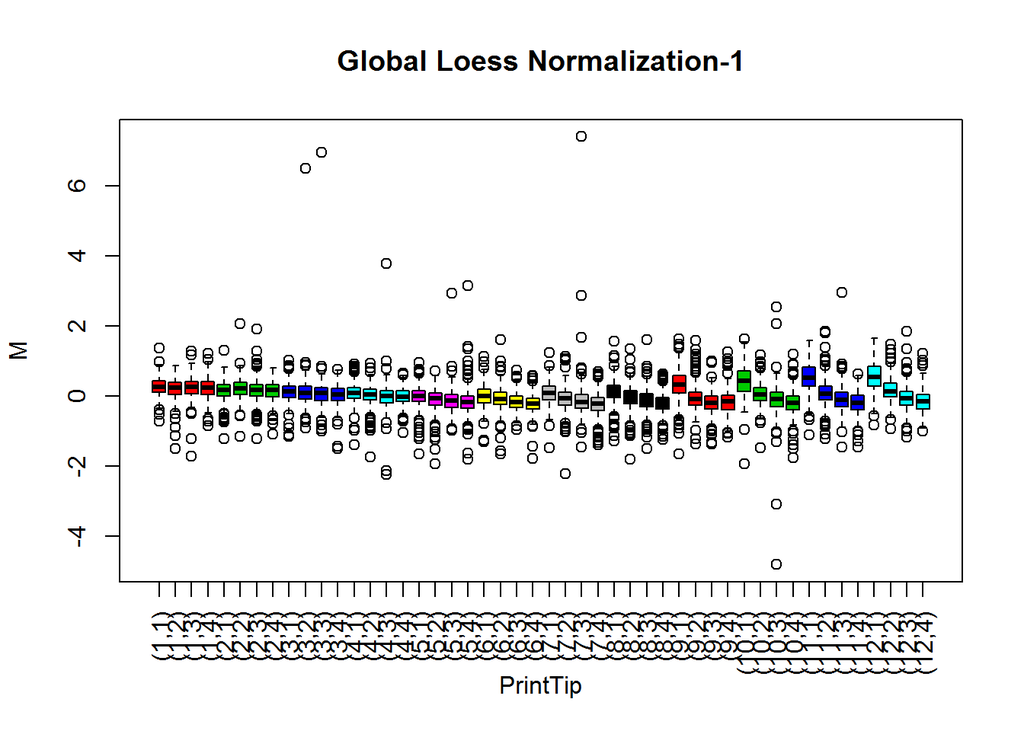

```r
boxplot(raw.data.norm.l[,1], xvar="maPrintTip", yvar="maM", main="Global Loess Normalization-1")
```

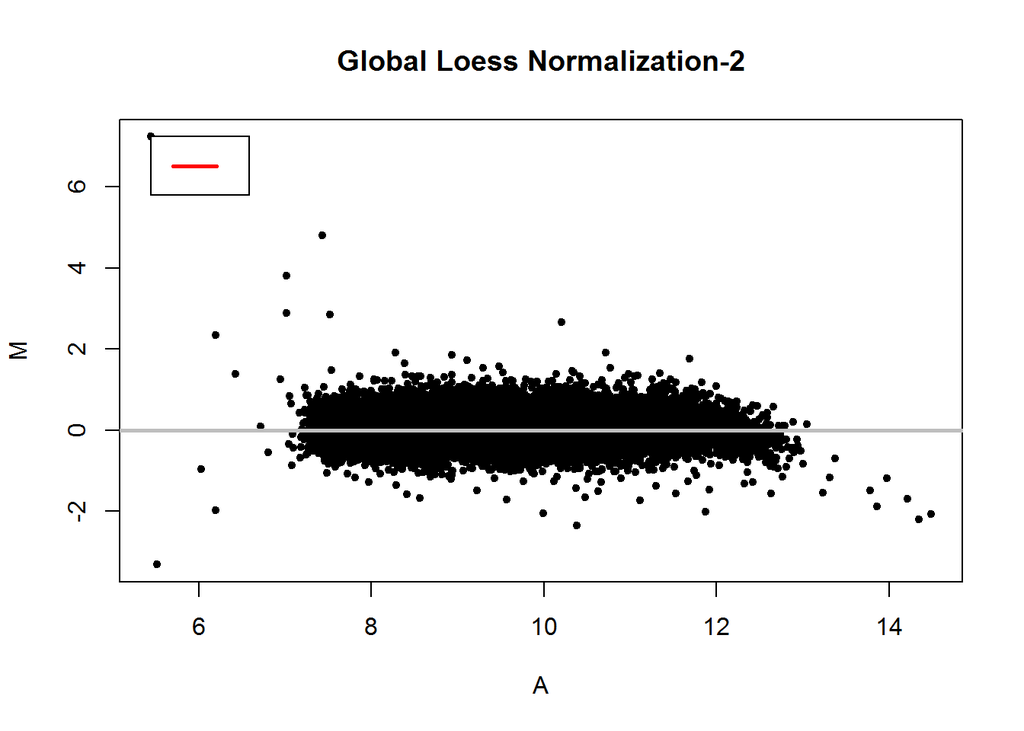

```r
maPlot(raw.data.norm.l[,2],x="maA",y="maM",z=NULL,lines.func=NULL, main="Global Loess Normalization-2")
```

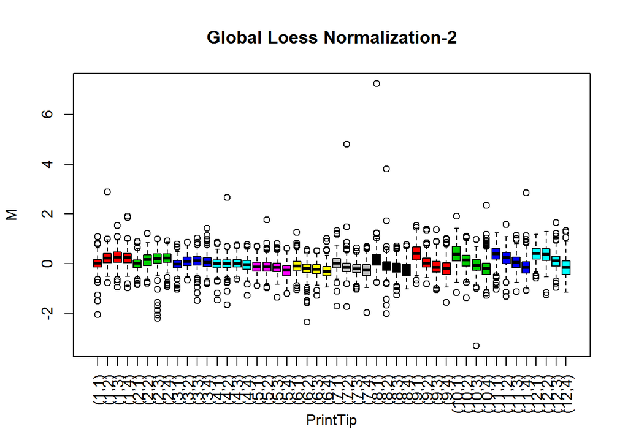

```r
boxplot(raw.data.norm.l[,2], xvar="maPrintTip", yvar="maM", main="Global Loess Normalization-2")
```

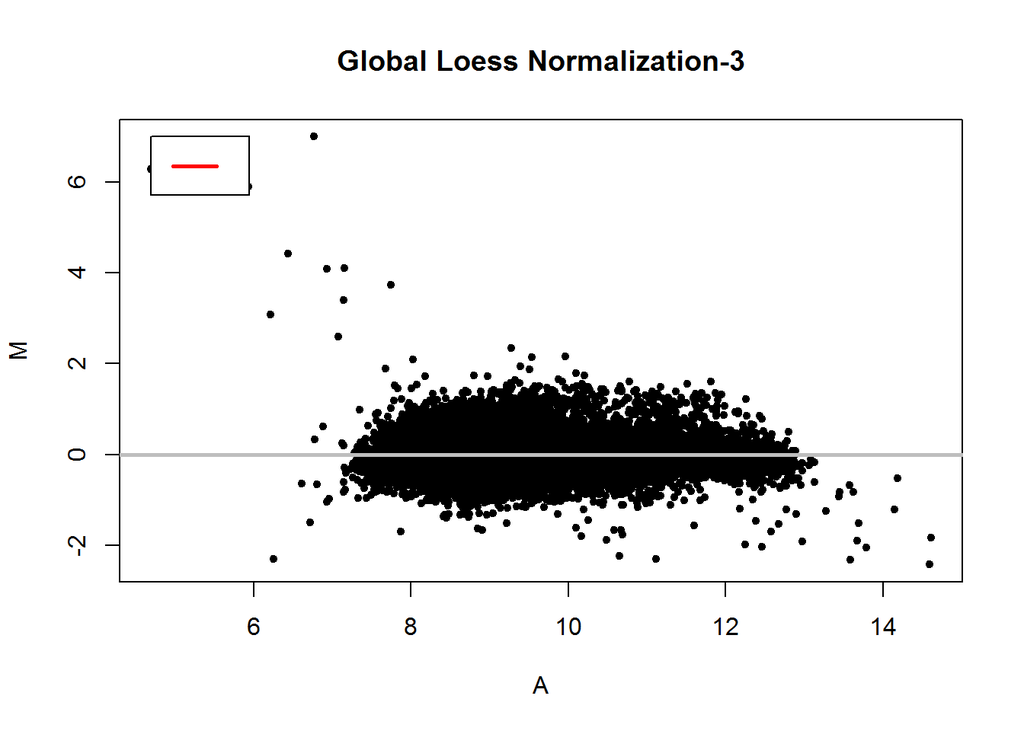

```r
maPlot(raw.data.norm.l[,3],x="maA",y="maM",z=NULL,lines.func=NULL, main="Global Loess Normalization-3")
```

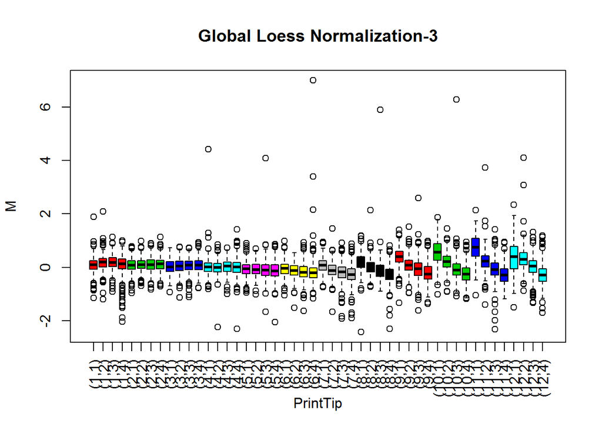

```r
boxplot(raw.data.norm.l[,3], xvar="maPrintTip", yvar="maM", main="Global Loess Normalization-3")
```

e.) Apply print tip loess normalization to the raw data; plot the MA plots and boxplots by print tip for this post normalized data.

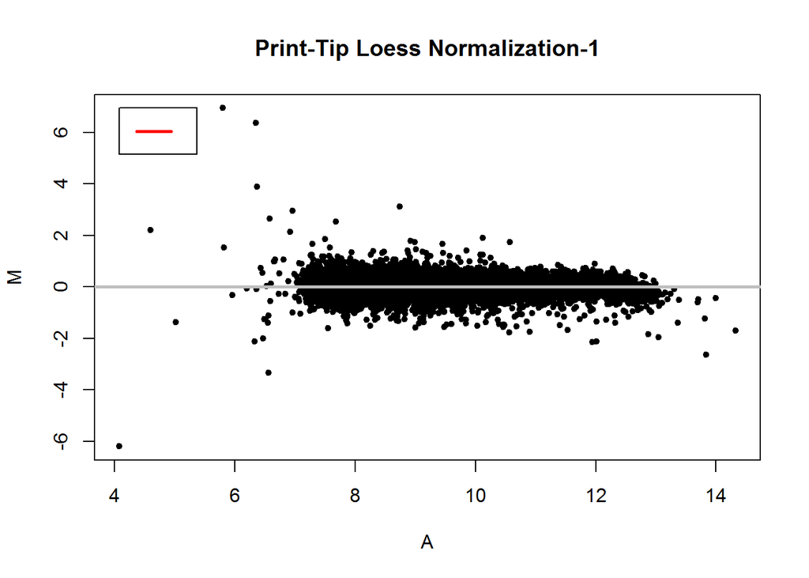

```r
raw.data.norm.p <- maNorm(raw.data, norm="printTipLoess")

maPlot(raw.data.norm.p[,1],x="maA",y="maM",z=NULL,lines.func=NULL, main="Print-Tip Loess Normalization-1")
```

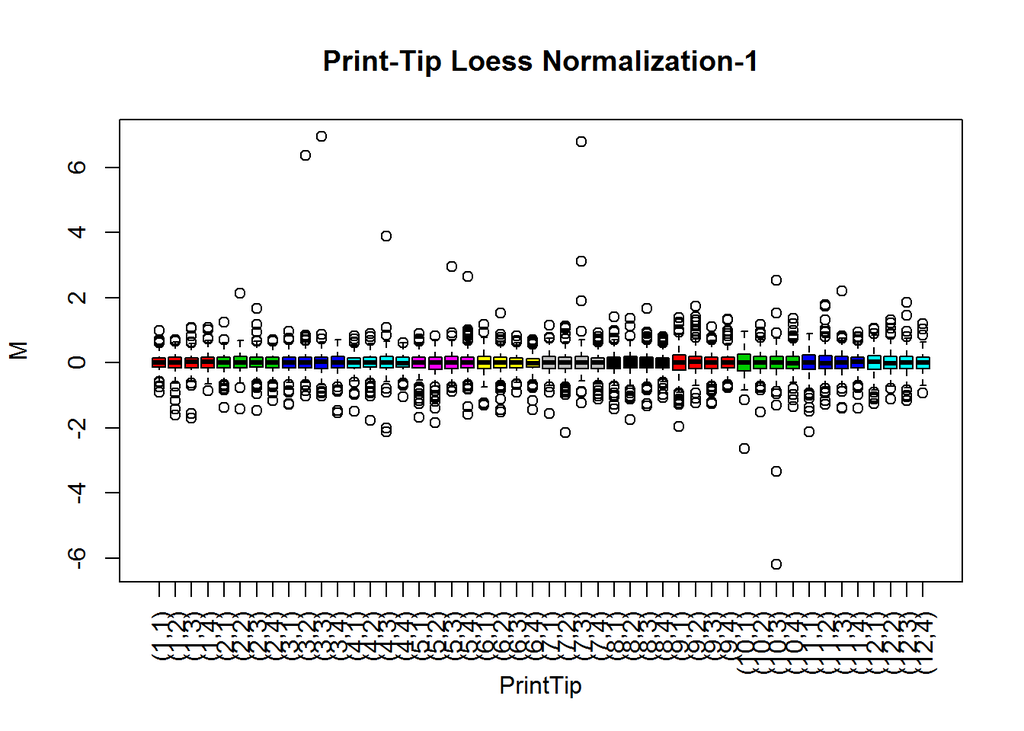

```r
boxplot(raw.data.norm.p[,1], xvar="maPrintTip", yvar="maM", main="Print-Tip Loess Normalization-1")
```

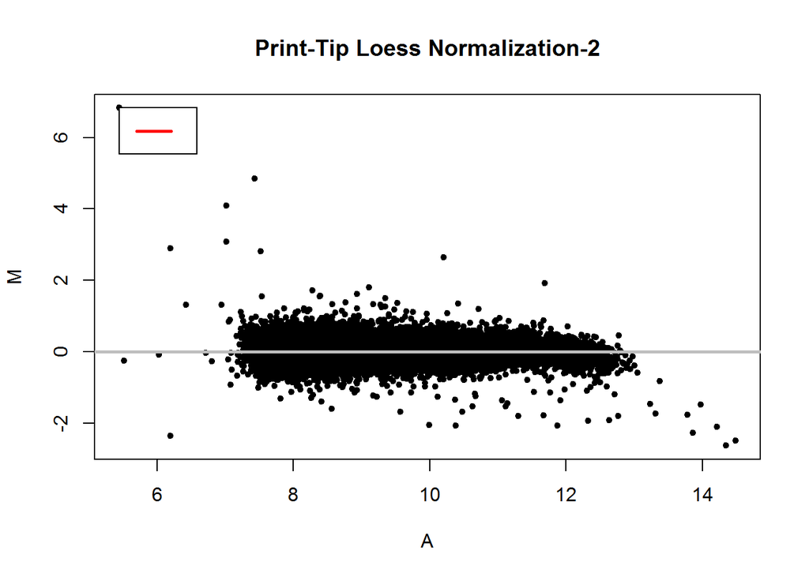

```r
maPlot(raw.data.norm.p[,2],x="maA",y="maM",z=NULL,lines.func=NULL, main="Print-Tip Loess Normalization-2")
```

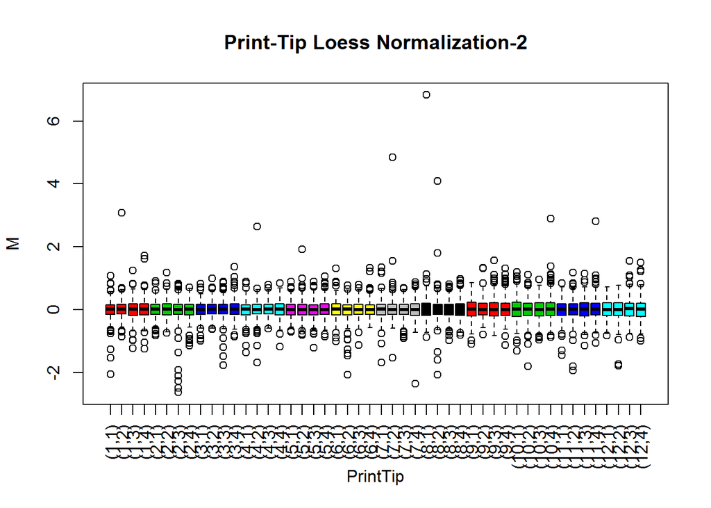

```r
boxplot(raw.data.norm.p[,2], xvar="maPrintTip", yvar="maM", main="Print-Tip Loess Normalization-2")
```

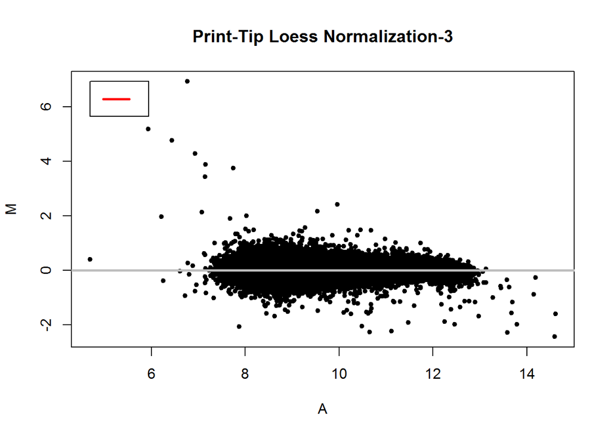

```r
maPlot(raw.data.norm.p[,3],x="maA",y="maM",z=NULL,lines.func=NULL, main="Print-Tip Loess Normalization-3")
```

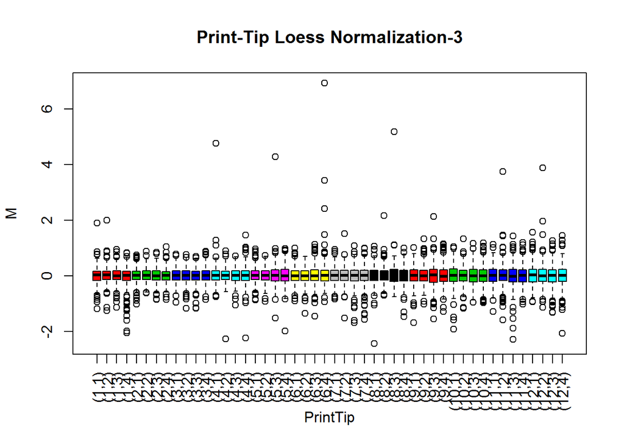

```r
boxplot(raw.data.norm.p[,3], xvar="maPrintTip", yvar="maM", main="Print-Tip Loess Normalization-3")
```

f.) Write a brief paragraph comparing and contrasting these normalization methods applied to this set of custom spotted array data.

All three methods do a fairly decent job of normalizing the data. Constant global normalization centers the MA plots around zero but does not do a good job of adjusting the skewness of the data. In addition the distribution of the box plots still vary quite a bit. Global Loess normalization does a much better job of eliminating the skewness of the data in the MA plots as well as centering their distribution around zero. However, the boxplots still vary. The Print-Tip Loess normalization does as well of a job as the global Loess normalization technique regarding the MA plots; however, the box plot distributions are much more compact and vary much less compared to the other normalization methods.